# Analyzing Plant Endemism in the Galápagos Islands and Livestock Mortality in East Africa Using R

R Statical Modeling

Mingke Dai

#### A. Specify the models

```r
setwd("/Users/mini/Desktop/PSYCH 463/Problem set/13")
d <- read.csv("PS_13_galapagos.csv", header = TRUE)

logit <- function(x) 1/(1+exp(-(x)))
log.area <- log(d$AREA)
log.elev <- log(d$ELEV)
log.distnear <- log(d$DISTNEAR)
log.areanear <- log(d$AREANEAR)

area <- (log.area - mean(log.area)) / (2 * sd(log.area))
elev <- (log.elev - mean(log.elev)) / (2 * sd(log.elev))
distnear <- (log.distnear - mean(log.distnear)) / (2 * sd(log.distnear))
areanear <- (log.areanear - mean(log.areanear)) / (2 * sd(log.areanear))

y_i ~ binom(a, N)
```

```
## y_i ~ binom(a, N)
```

```r
y_i ~ binom(a + ba * area_i, N)
```

```
## y_i ~ binom(a + ba * area_i, N)
```

```r
y_i ~ binom(a + be * elev_i, N)
```

```
## y_i ~ binom(a + be * elev_i, N)
```

```r
y_i ~ binom(a + bdistnear * distnear_i, N)
```

```
## y_i ~ binom(a + bdistnear * distnear_i, N)
```

```r
y_i ~ binom(a + bareanear * areanear_i, N)
```

```
## y_i ~ binom(a + bareanear * areanear_i, N)
```

```r
y_i ~ binom(a + bnear * areanear_i * distnear_i, N)
```

```
## y_i ~ binom(a + bnear * areanear_i * distnear_i, N)
```

#### B. Simulate data from the models

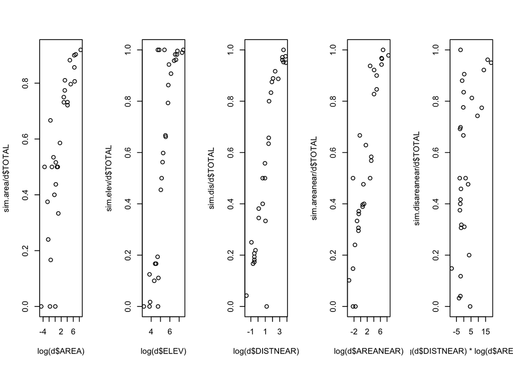

```r
a <- 0.5
ba <- 2
be <- 6
bdistnear <- 4
barearnear <- 3.5
bnear <- 9

sim.intercept <- rbinom(length(d$TOTAL),
                      prob = 0.5,
                      size = d$TOTAL)

sim.area <- rbinom(30,
                      prob = logit(a + ba * area),
                      size = d$TOTAL)

sim.elev <- rbinom(30,
                    prob = logit(a + be * elev),
                    size = d$TOTAL)

sim.dis <- rbinom(30,
                    prob = logit(a + bdistnear * distnear),
                    size = d$TOTAL)

sim.areanear <- rbinom(30,
                    prob = logit(a + barearnear * areanear),
                    size = d$TOTAL)

sim.disareanear <- rbinom(30,
                    prob = logit(a + bnear * distnear * areanear),
                    size = d$TOTAL)

par(mfrow = c(1, 5))
plot(sim.area / d$TOTAL ~ log(d$AREA))
plot(sim.elev / d$TOTAL ~ log(d$ELEV))
plot(sim.dis / d$TOTAL ~ log(d$DISTNEAR))
plot(sim.areanear / d$TOTAL ~ log(d$AREANEAR))
plot(sim.disareanear / d$TOTAL ~ I(log(d$DISTNEAR) * log(d$AREANEAR)))
```

#### C. Specify likelihood functions for the models

```r
#intercept
dbinom(d$NATIVE,
       size = d$TOTAL,
       prob = logit(a),
       log = TRUE)
```

```
##  [1]   -8.2830248   -2.0887144   -1.4222310   -5.3220070   -0.7550068
##  [6]   -1.6654097   -2.5675472   -1.4532781   -1.5441206   -0.9481540
## [11]  -27.4947746  -13.9637394  -15.0794589   -1.2609470   -3.8624627
## [16]  -98.9573180   -5.2647523   -0.9481540  -17.6129642  -24.7142352
## [21]   -1.7952963   -7.7252214  -91.3982437  -41.0621829 -157.5589097
## [26]   -5.9971620  -81.8698126   -8.1037194   -2.1225774   -1.8645197
```

```r
sum (-dbinom(d$NATIVE,
       size = d$TOTAL,
       prob = logit(a),
       log = TRUE))
```

```
## [1] 634.7059
```

```r
# area
dbinom(d$NATIVE,
       size = d$TOTAL,
       prob = logit(a + ba * area),
       log = TRUE)
```

```
##  [1]  -15.686597   -3.478253   -2.818689   -1.826833   -0.693349   -2.918910
##  [7]   -3.377947   -1.705066   -2.285648   -1.934736  -57.097083  -64.404333
## [13]   -5.639759   -1.946709   -6.498575 -476.389326  -18.279273   -3.141220
## [19]  -43.176456  -38.693481   -4.435191   -7.456137 -292.792719 -177.358921
## [25] -530.429377  -12.139311 -219.855838   -5.105816   -1.639625   -1.752905
```

```r
sum (-dbinom(d$NATIVE,
       size = d$TOTAL,
       prob = logit(a + ba * area),
       log = TRUE))
```

```
## [1] 2004.958
```

```r
# elev
dbinom(d$NATIVE,
       size = d$TOTAL,
       prob = logit(a + be * elev),
       log = TRUE)
```

```
##  [1]   -33.5537733   -17.8363921    -4.4411439   -19.6899557    -0.8719249
##  [6]    -6.9252724   -10.3437643    -2.4668568   -10.8870676    -3.0369446
## [11]   -21.3035901  -283.7296288   -29.2561719    -1.1157246   -22.6252130
## [16] -1425.3697258   -25.9114278   -10.8613499  -210.9252672  -140.8472035
## [21]   -14.6495709   -43.9717957  -688.7725951  -558.5603452 -1310.0049832
## [26]   -13.9358516  -603.0751668    -2.2360857    -1.6637006    -2.9428828
```

```r
sum (-dbinom(d$NATIVE,
       size = d$TOTAL,
       prob = logit(a + be * elev),
       log = TRUE))
```

```
## [1] 5521.811
```

```r
# distnear
dbinom(d$NATIVE,
       size = d$TOTAL,
       prob = logit(a + bdistnear * distnear),
       log = TRUE)
```

```
##  [1]  -11.9775652  -23.1311408   -1.7299568   -2.1392343   -0.7074591
##  [6]   -4.0215821   -5.9560844   -5.7239409   -5.3926668   -1.2371812
## [11]   -2.4530529  -21.4434359   -2.1807399   -1.0087121  -55.2471949
## [16]   -8.7404678  -58.5733677   -0.9825216 -152.9984789  -95.7250142
## [21]  -13.5233887  -12.8320157 -663.5587077 -110.2948398   -8.3034334
## [26]  -48.9180983  -49.9422505   -7.7348075   -5.0957079  -18.6459089
```

```r
sum (-dbinom(d$NATIVE,
       size = d$TOTAL,
       prob = logit(a + bdistnear * distnear),
       log = TRUE))
```

```
## [1] 1400.219
```

```r
# areanear
dbinom(d$NATIVE,
       size = d$TOTAL,
       prob = logit(a + barearnear * areanear),
       log = TRUE)
```

```
##  [1]   -2.975152  -13.686345   -3.028598   -3.348923   -2.604856   -2.323905
##  [7]   -4.712294   -1.893165   -2.494787   -3.661016   -3.174725 -180.119302
## [13]  -48.200805   -4.675249  -24.457894 -603.627624  -24.545733   -3.661016
## [19]  -91.989172  -22.236127   -1.399046  -77.027582   -8.890556  -36.299336
## [25]  -14.506822   -4.783616  -11.431710  -20.273353   -4.023910   -1.923248
```

```r
sum (-dbinom(d$NATIVE,
       size = d$TOTAL,
       prob = logit(a + barearnear * areanear),
       log = TRUE))
```

```
## [1] 1227.976
```

```r
# distnear * areanear
dbinom(d$NATIVE,
       size = d$TOTAL,
       prob = logit(a + bnear * distnear * areanear),
       log = TRUE)
```

```
##  [1]  -23.6877887  -46.5957013   -1.2388303  -13.1090994   -0.8463959
##  [6]   -1.9475689   -1.9249680   -2.5321548   -1.6282899   -0.6384816
## [11]  -78.7243532  -33.7525482   -2.4990304   -1.7427397  -60.5887195
## [16]  -71.4784730  -45.7381751   -0.9020888 -166.6072993  -17.4439301
## [21]   -5.9798535  -16.5645924  -18.5273752  -53.1414716 -615.4385358
## [26]   -8.4850405 -139.0661201   -2.1092774   -3.0179729   -2.8963727
```

```r
sum (-dbinom(d$NATIVE,
       size = d$TOTAL,
       prob = logit(a + bnear * distnear * areanear),
       log = TRUE))
```

```
## [1] 1438.853
```

#### D. Validate code

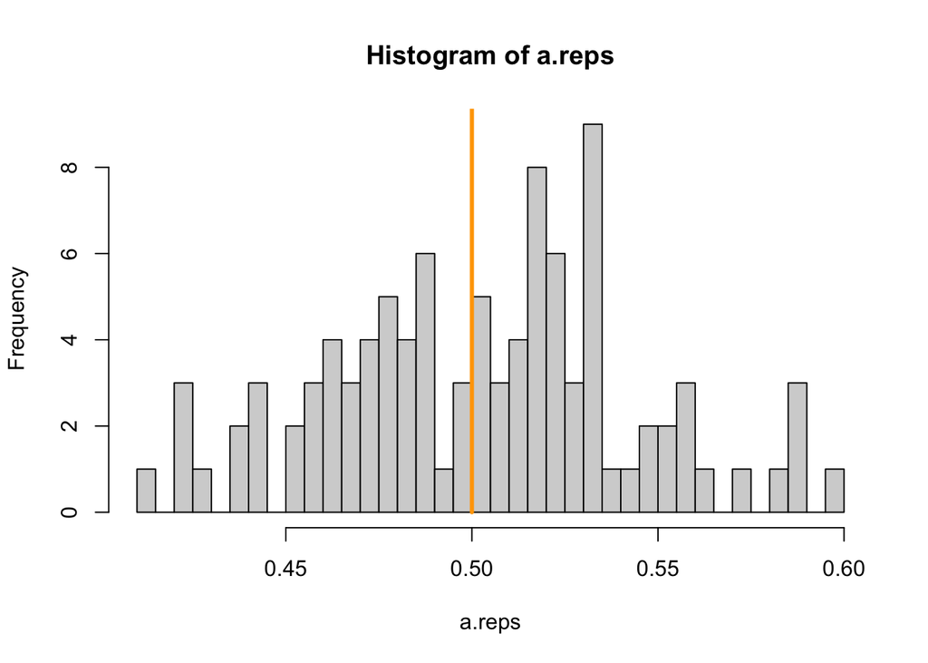

```r
par(mfrow = c(1, 1))

#a
rep.m <- function(a) {
y1 <- rbinom(length(d$TOTAL),
              prob = logit(a),
              size = d$TOTAL)
m1 <- mle2(y1 ~ dbinom(size = d$TOTAL,
                       prob = logit(a)),
           start = list(a = 0.5),
           data = list(y1 = y1))
coef(m1)
}

a.p <- 0.5
a.reps <- replicate(99, rep.m(a.p))
hist(a.reps, breaks = 50)
lines(c(a.p, a.p), c(0, 10000), lwd = 3, col = "orange")
```

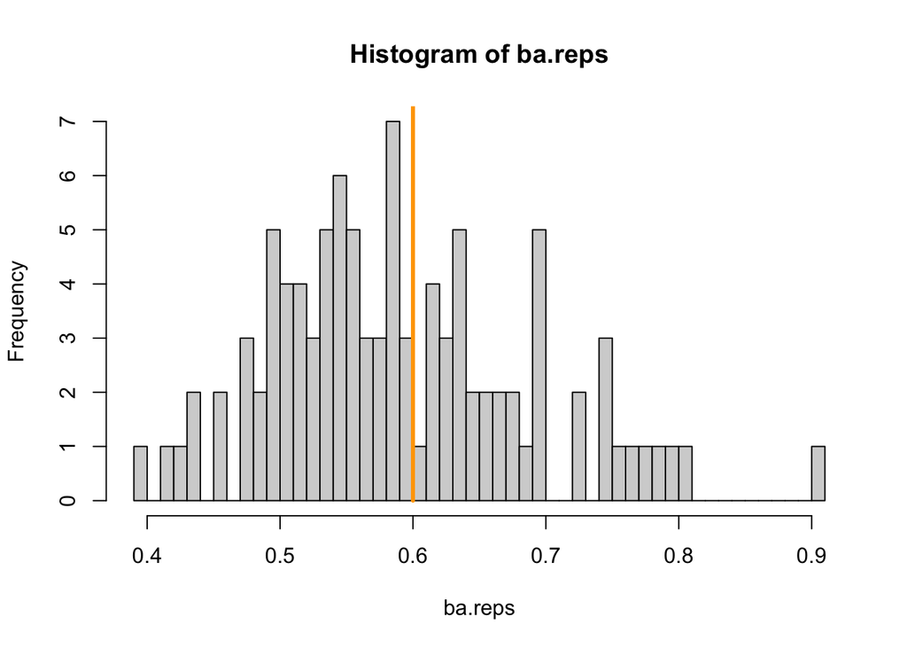

```r
#ba
rep.m <- function(ba) {
y2 <- rbinom(length(d$TOTAL),
              prob = logit(a + ba * area),
              size = d$TOTAL)
m2 <- mle2(y2 ~ dbinom(size = d$TOTAL,
                       prob = logit(a + ba * area)),
           start = list(a = 0, ba = 0),
           data = list(y2 = y2))
coef(m2)["ba"]
}

ba.p <- 0.6
ba.reps <- replicate(99, rep.m(ba.p))
hist(ba.reps, breaks = 50)
lines(c(ba.p, ba.p), c(0, 10000), lwd = 3, col = "orange")
```

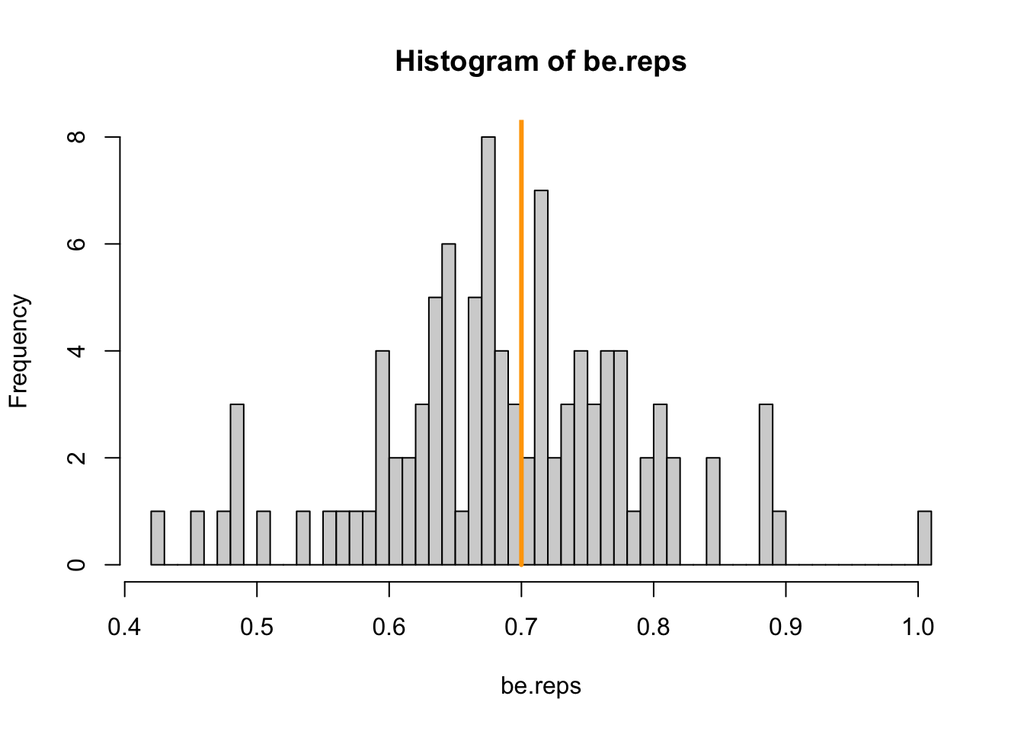

```r
#be
rep.m <- function(be) {
y3 <- rbinom(length(d$TOTAL),
              prob = logit(a + be * elev),
              size = d$TOTAL)
m3 <- mle2(y3 ~ dbinom(size = d$TOTAL,
                       prob = logit(a + be * elev)),
           start = list(a = 0, be = 0),
           data = list(y3 = y3))
coef(m3)["be"]
}

be.p <- 0.7
be.reps <- replicate(99, rep.m(be.p))
hist(be.reps, breaks = 50)
lines(c(be.p, be.p), c(0, 10000), lwd = 3, col = "orange")
```

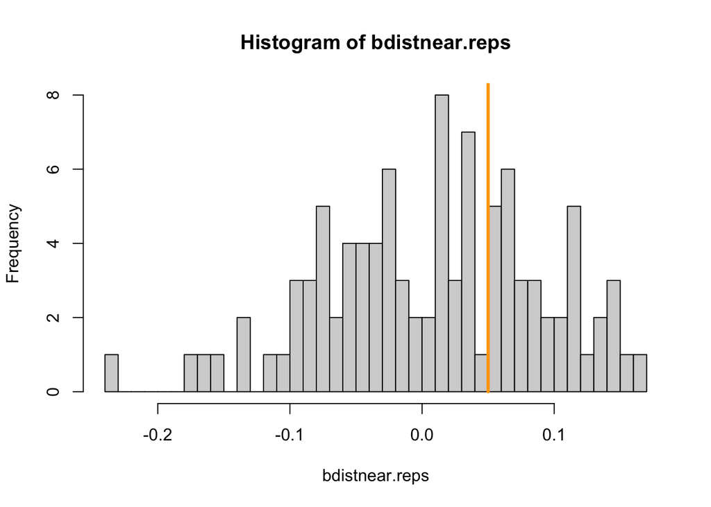

```r
#bdistnear
rep.m <- function(distnear) {
y4 <- rbinom(length(d$TOTAL),
              prob = logit(a + bdistnear * distnear),
              size = d$TOTAL)
m4 <- mle2(y4 ~ dbinom(size = d$TOTAL,
                       prob = logit(a + bdistnear * distnear)),
           start = list(a = 0, bdistnear = 0),
           data = list(y4 = y4))
coef(m4)["bdistnear"]
}

bdistnear.p <- 0.05
bdistnear.reps <- replicate(99, rep.m(bdistnear.p))
hist(bdistnear.reps, breaks = 50)
lines(c(bdistnear.p, bdistnear.p),
      c(0, 10000), lwd = 3, col = "orange")
```

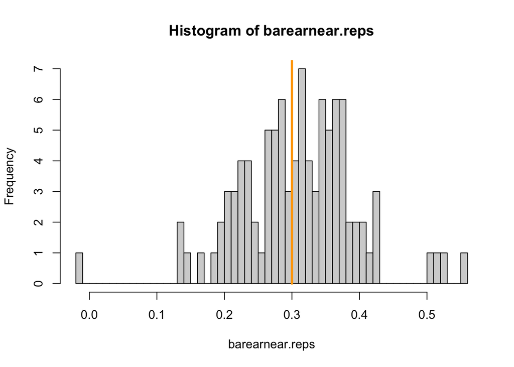

```r
#bareanear
rep.m <- function(barearnear) {
y5 <- rbinom(length(d$TOTAL),
              prob = logit(a + barearnear * areanear),
              size = d$TOTAL)
m5 <- mle2(y5 ~ dbinom(size = d$TOTAL,
                       prob = logit(a + barearnear * areanear)),
           start = list(a = 0, barearnear = 0),
           data = list(y5 = y5))
coef(m5)["barearnear"]
}

barearnear.p <- 0.3
barearnear.reps <- replicate(99, rep.m(barearnear.p))
hist(barearnear.reps, breaks = 50)
lines(c(barearnear.p, barearnear.p), c(0, 10000), lwd = 3, col = "orange")
```

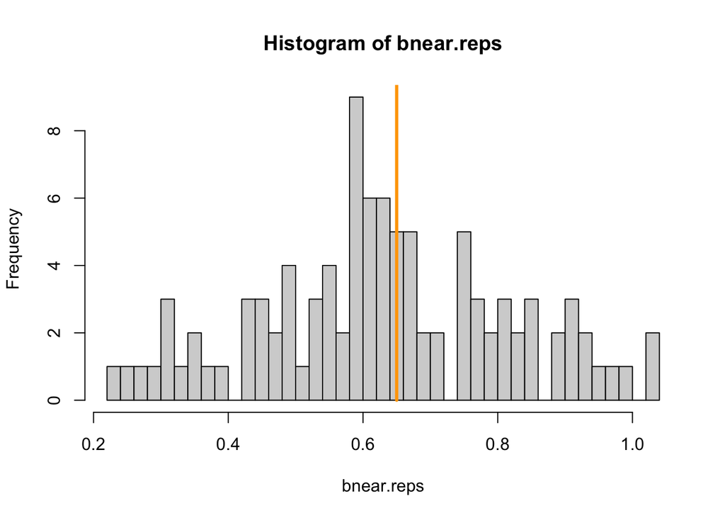

```r
#bnear
rep.m <- function(bnear) {
y6 <- rbinom(length(d$TOTAL),
              prob = logit(a + bnear * distnear * areanear),
              size = d$TOTAL)
m6 <- mle2(y6 ~ dbinom(size = d$TOTAL,
                       prob = logit(a + bnear * distnear * areanear)),
           start = list(a = 0, bnear = 0),
           data = list(y6 = y6))
coef(m6)["bnear"]
}

bnear.p <- 0.65
bnear.reps <- replicate(99, rep.m(bnear.p))
hist(bnear.reps, breaks = 50)
lines(c(bnear.p, bnear.p), c(0, 10000), lwd = 3, col = "orange")
```

#### E. Fit models to the actual data

```r
mintercept <- mle2(NATIVE ~ dbinom(prob = logit(a),
                                     size = TOTAL),
                   start = list(a = 0),
                   data = d)

marea <- mle2(NATIVE ~ dbinom(size = TOTAL,
                        prob = logit(a + ba * area)),
                        start = list(a = 0, ba = 0),
                        data = d)

melev <- mle2(NATIVE ~ dbinom(size = TOTAL,
                        prob = logit(a + be * elev)),
                        start = list(a = 0, be = 0),
                        data = d)

mdis <- mle2(NATIVE ~ dbinom(size = TOTAL,
                        prob = logit(a + bdistnear * distnear)),
                        start = list(a = 0, bdistnear = 0),
                        data = d)

mareanear <- mle2(NATIVE ~ dbinom(size = TOTAL,
                        prob = logit(a + barearnear * areanear)),
                        start = list(a = 0, barearnear = 0),
                        data = d)

mdisareanear <- mle2(NATIVE ~ dbinom(size = TOTAL,
                     prob = logit(a + bnear * distnear *
                                    areanear)),
                     start = list(a = 0, bnear = 0),
                     data = d)
```

#### F. Compare the models and interpret their estimates

```r
AICtab(mintercept, marea, melev, mdis, mareanear, mdisareanear, weights = TRUE, nobs = sum(d$TOTAL))
```

```
##              dAIC df weight
## marea         0.0 2  1
## melev        21.3 2  <0.001
## mareanear    54.5 2  <0.001
## mdis         61.1 2  <0.001
## mintercept   63.0 1  <0.001
## mdisareanear 64.8 2  <0.001
```

```r
exp(coef(marea))
```

```
##         a        ba
## 0.6890061 0.4198628
```

**Answer:** Based on the AIC model comparison, the marea model is the best. It has the lower AIC value and dominates the Akaike weight (100%). The second and third hypothesis have weak support because the weights are all under 0.1%. Back transforming the intercept value gives us the baseline odds of surviving. The endemic species begins with a baseline odds of 0.689 of successfully surviving on island. As the area increase, then odds decrease by 0.42 times. It support the first hypothesis: larger islands have proportionately fewer endemic species.

## Exercise 2. East African livestock

#### A.

```r
data <- read.csv("PS_13_rinder.csv", header = TRUE)
data$s <- ifelse(data$stock == "large", 1, 0)

m1 <- mle2(data$mortality ~ dbinom(prob = logit(a + b * data$s),
                                 size = data$n),
           start = list(a = 0, b = 0), data = data)

exp(coef(m1))
```

```
##         a         b
## 1.0313862 0.8825115
```

```r
logit(0.031+(-0.125))
```

```
## [1] 0.4765173
```

```r
0.5077253-0.4765173
```

```
## [1] 0.031208
```

#### B.

```r
m2 <- mle2(data$mortality ~ dbinom(size = n,
                                 prob = logit(a)),
                                 start = list(a = 0), data = data)
```

#### C.

```r
AICtab(m1, m2, base = TRUE, weights = TRUE)
```

```
##    AIC   dAIC  df weight
## m1 871.4   0.0 2  0.911
## m2 876.1   4.7 1  0.089
```

**Answer:** The m1 model is better than m2, and it has 91.1% weight. It means that stock size is a good predictor to explain the data set, but still there are other factors not including in the model (weight is not 1).

#### D.

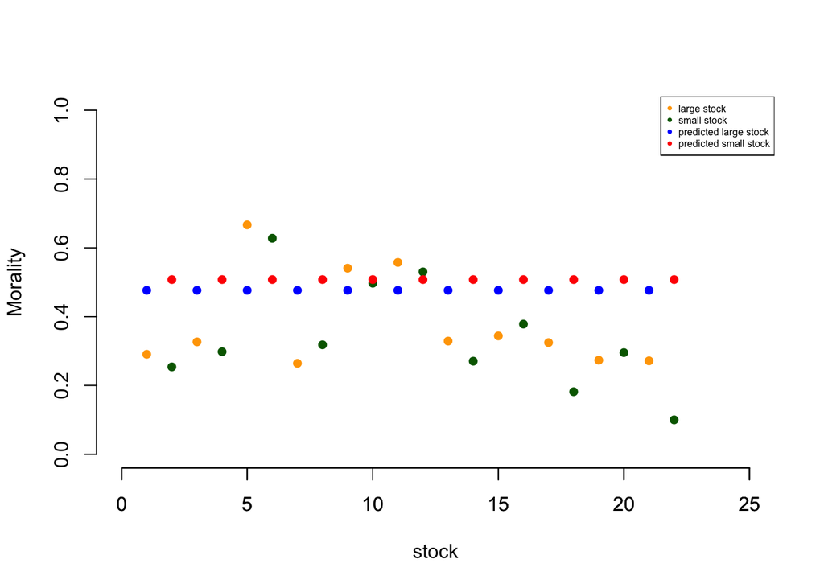

```r
plot(data$mortality/n ~ 1,
     data = data,
     pch = 16,
     col = ifelse(data$s == 1, "orange", "darkgreen"),
     xlim = c(0, 25),
     ylim = c(0, 1),
     xlab = "stock",
     ylab = "Morality",
     bty = "n")

axis(side = 1,
     at = c(0, 5, 10, 15, 20, 25),
     labels = c("0", "5", "10", "15", "20", "25"))

data.p <- data.frame(data$s)

value.p <- predict(m1, data.p, type = "response")

points <- data.frame(x = seq(1, 22),
                     predicted = value.p,
                     total = data$n,
                     stock = data$s)

points(x = points$x[points$stock == 1],
       y = points$predicted[points$stock == 1]/points$total[points$stock == 1],
       pch = 16, col = "blue")

points(x = points$x[points$stock == 0],
       y = points$predicted[points$stock == 0]/points$total[points$stock == 0],
       pch = 16,
       col = "red")


legend("topright", pch = 16,
       col = c("orange", "darkgreen", "blue", "red"),
       legend = c("large stock","small stock",
                  "predicted large stock","predicted small stock"),
       cex = 0.5)
```

**Answer:** The predicted value relatively close to the original value but almost all did not get predicted correctly (with at least 0.1 difference). The predicted data is also fail to follow the trend of the original data set.

#### E. (i)

```r
#m1 <- lmer(mortality ~ stock + ( 1 | herd), data = data)

m.glmm <- glmer(cbind(mortality, n - mortality) ~ (1|herd) +
                  s + (0 + s|herd),
              data = data, family = binomial)
```

```
## boundary (singular) fit: see help('isSingular')
```

```r
summary(m.glmm)
```

```
## Generalized linear mixed model fit by maximum likelihood (Laplace
##   Approximation) [glmerMod]
##  Family: binomial  ( logit )
## Formula: cbind(mortality, n - mortality) ~ (1 | herd) + s + (0 + s | herd)
##    Data: data
##
##      AIC      BIC   logLik deviance df.resid
##    190.9    195.3    -91.5    182.9       18
##
## Scaled residuals:
##      Min       1Q   Median       3Q      Max
## -1.75007 -0.26378 -0.06272  0.23031  1.04446
##
## Random effects:
##  Groups Name        Variance Std.Dev.
##  herd   (Intercept) 0.3136   0.56
##  herd.1 s           0.0000   0.00
## Number of obs: 22, groups:  herd, 11
##
## Fixed effects:
##             Estimate Std. Error z value Pr(>|z|)
## (Intercept) -0.65713    0.17685  -3.716 0.000203 ***
## s            0.15429    0.05149   2.997 0.002730 **
## ---
## Signif. codes:  0 '***' 0.001 '**' 0.01 '*' 0.05 '.' 0.1 ' ' 1
##
## Correlation of Fixed Effects:
##   (Intr)
## s -0.237
## optimizer (Nelder_Mead) convergence code: 0 (OK)
## boundary (singular) fit: see help('isSingular')
```

#### E. (iii)

**Answer:** One unit of increase in large stock would increase the mortality rate by 15%, compared to small stock with a standard deviation of 0.05 when controlling the effect among herds. It is not the same. The direction of the effect of being large stock or small stock (stock size) is even opposite.

#### E. (iv)

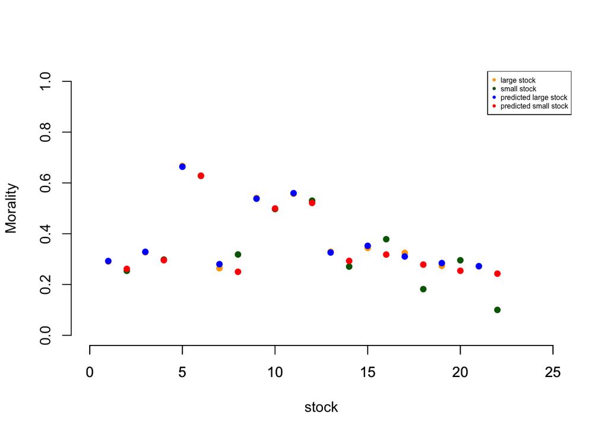

```r
plot(data$mortality/n ~ 1,
     data = data,
     pch = 16,
     col = ifelse(data$s == 1, "orange", "darkgreen"),
     xlim = c(0, 25),
     ylim = c(0, 1),
     xlab = "stock",
     ylab = "Morality",
     bty = "n")

axis(side = 1, at = c(0, 5, 10, 15, 20, 25),
     labels = c("0", "5", "10", "15", "20", "25"))

data.p <- data.frame(s = data$s, herd = data$herd)

value.p <- predict(m.glmm, data.p, type = "response")

points <- data.frame(x = seq(1, 22),
                     predicted = value.p,
                     total = data$n,
                     stock = data$s)

points(x = points$x[points$stock == 1],
       y = points$predicted[points$stock == 1],
       pch = 16,
       col = "blue")

points(x = points$x[points$stock == 0],
       y = points$predicted[points$stock == 0],
       pch = 16,
       col = "red")

legend("topright", pch = 16,
       col = c("orange", "darkgreen", "blue", "red"),
       legend = c("large stock","small stock",
                  "predicted large stock","predicted small stock"),
       cex = 0.5)
```

**Answer:** Based on the graph, m.glmm predicts the mortality pretty well, better than fixed effect model (m1). Almost all morality levels from the original data set get predicted. Some missed but without a big distance probably due to shrink.

#### E. (v)

```r
AICtab(m1, m.glmm, weights = TRUE)
```

```
##        dAIC  df weight
## m.glmm   0.0 4  1
## m1     680.5 2  <0.001
```

**Answer:** m.glmm is much better than m1 according to AIC with a weight of 1. The dAIC of m1 is 680.5, indicating it won’t be the best model.